# Assignment 7

## Try to submit as an HTML file

Print your name below

```python
print("Sigrid Matthews")
```

```
Sigrid Matthews
```

Import the "pandas" and "numpy" library

```python
# Write your answer here:

import pandas as pd
import numpy as np
```

(a) Replace values from intervals

- Import the dataset "data_raw/students.csv" to a new object "students"
- Use "pd.cut()" to assign the column "numericgrade" to a letter grade

using the following table

[figure not shown]

HINT: See Lecture 13

For questions (b)-(e) use "results.csv",  
a dataset on competitive car racing

Import the dataset "data/raw_results.csv" to  
a new object "results"

```python
# Write your own code
letter_grades = ["F","D","C-","C","C+","B-","B","B+","A-","A"]
grade_bins = [-1, 54, 59, 64, 69, 74, 79, 82, 86, 92, 100]
students = pd.read_csv("data_raw/students.csv")
students["lettergrade"] = pd.cut(students["numericgrade"],
                                bins = grade_bins,
                                right = True,
                                labels = letter_grades)
display(students)
```

|  | studentid | numericgrade | lettergrade |
| --- | --- | --- | --- |
| 0 | 1 | 61 | C- |
| 1 | 2 | 0 | F |
| 2 | 3 | 14 | F |
| 3 | 4 | 57 | D |
| 4 | 5 | 72 | C+ |
| 5 | 6 | 93 | A |
| 6 | 7 | 40 | F |
| 7 | 8 | 11 | F |
| 8 | 9 | 3 | F |
| 9 | 10 | 63 | C- |
| 10 | 11 | 7 | F |
| 11 | 12 | 46 | F |
| 12 | 13 | 75 | B- |
| 13 | 14 | 95 | A |
| 14 | 15 | 22 | F |
| 15 | 16 | 40 | F |
| 16 | 17 | 53 | F |
| 17 | 18 | 57 | D |
| 18 | 19 | 82 | B |
| 19 | 20 | 50 | F |
| 20 | 21 | 8 | F |
| 21 | 22 | 87 | A- |
| 22 | 23 | 82 | B |
| 23 | 24 | 30 | F |
| 24 | 25 | 62 | C- |

(b) Check column types

- View the dataset
- Use the function "results.dtypes" to get the column types
- Search for the "results" table in "codebook/f1_codebook.pdf".
- Does the type of the "milliseconds" column agree with the codebook?

i.e. is it an integer, float, or string/object?

HINT: See Lectures 13 and 14 for how to interpret the codebook

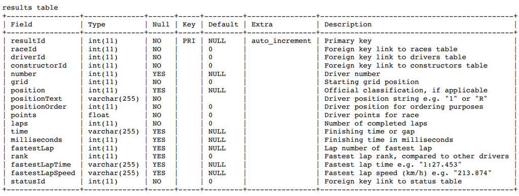

```python
# Write your own code here
# Note: When you run "results.dtypes" you will get the type (int, float, object)
# Object represents columns coded as strings.
results = pd.read_csv("data_raw/results.csv")
display(results)
results.dtypes
print("The codebook and dtype for milliseconds do not match. It is an integer in the codebook and an object/string in the table column")
```

|  | resultId | raceId | driverId | constructorId | number | grid | position | positionText | positionOrder | points | laps | time | milliseconds | fastestLap | rank | fastestLapTime | fastestLapSpeed | statusId |
| --- | --- | --- | --- | --- | --- | --- | --- | --- | --- | --- | --- | --- | --- | --- | --- | --- | --- | --- |
| 0 | 1 | 18 | 1 | 1 | 22 | 1 | 1 | 1 | 1 | 10.0 | 58 | 1:34:50.616 | 5690616 | 39 | 2 | 1:27.452 | 218.300 | 1 |
| 1 | 2 | 18 | 2 | 2 | 3 | 5 | 2 | 2 | 2 | 8.0 | 58 | +5.478 | 5696094 | 41 | 3 | 1:27.739 | 217.586 | 1 |
| 2 | 3 | 18 | 3 | 3 | 7 | 7 | 3 | 3 | 3 | 6.0 | 58 | +8.163 | 5698779 | 41 | 5 | 1:28.090 | 216.719 | 1 |
| 3 | 4 | 18 | 4 | 4 | 5 | 11 | 4 | 4 | 4 | 5.0 | 58 | +17.181 | 5707797 | 58 | 7 | 1:28.603 | 215.464 | 1 |
| 4 | 5 | 18 | 5 | 1 | 23 | 3 | 5 | 5 | 5 | 4.0 | 58 | +18.014 | 5708630 | 43 | 1 | 1:27.418 | 218.385 | 1 |
| ... | ... | ... | ... | ... | ... | ... | ... | ... | ... | ... | ... | ... | ... | ... | ... | ... | ... | ... |
| 25835 | 25841 | 1096 | 854 | 210 | 47 | 12 | 16 | 16 | 16 | 0.0 | 57 | \N | \N | 39 | 12 | 1:29.833 | 211.632 | 11 |
| 25836 | 25842 | 1096 | 825 | 210 | 20 | 16 | 17 | 17 | 17 | 0.0 | 57 | \N | \N | 40 | 20 | 1:31.158 | 208.556 | 11 |
| 25837 | 25843 | 1096 | 1 | 131 | 44 | 5 | 18 | 18 | 18 | 0.0 | 55 | \N | \N | 42 | 11 | 1:29.788 | 211.738 | 9 |
| 25838 | 25844 | 1096 | 849 | 3 | 6 | 20 | 19 | 19 | 19 | 0.0 | 55 | \N | \N | 45 | 14 | 1:30.309 | 210.517 | 130 |
| 25839 | 25845 | 1096 | 4 | 214 | 14 | 10 | \N | R | 20 | 0.0 | 27 | \N | \N | 24 | 17 | 1:30.579 | 209.889 | 47 |

25840 rows × 18 columns

```
The codebook and dtype for milliseconds do not match. It is an integer in the codebook and an object/string in the table column
```

(c) Clean a column

- Import the dataset "data_raw/results.csv" to a new object "results"
- Our goal is to replace any string values in the column "milliseconds"

to missing values (NaNs) and covert to numeric

- To do so, go to Lecture 13 and follow the setups under the headings
  - "Extract list of non-numeric values"
  - "Replace certain values"
  - "Convert column to numeric"

HINT: substitute "milliseconds" instead of "alt",  
and the dataset "results" instead of "circuits"

```python
# Write your own code here
results["milliseconds"].str.isnumeric()
subset      = results.query("milliseconds.str.isnumeric() == False")
list_unique = pd.unique(subset["milliseconds"])
print(list_unique)
list_old = ["\\N"]
list_new = [np.nan]

results["milliseconds"] = results["milliseconds"].replace(list_old, list_new,inplace=True)
results["milliseconds_numeric"] = pd.to_numeric(results["milliseconds"])
results.dtypes
```

[output not shown]

```
resultId                  int64
raceId                    int64
driverId                  int64
constructorId             int64
number                   object
grid                      int64
position                 object
positionText             object
positionOrder             int64
points                  float64
laps                      int64
time                     object
milliseconds             object
fastestLap               object
rank                     object
fastestLapTime           object
fastestLapSpeed          object
statusId                  int64
milliseconds_numeric    float64
dtype: object
```

(d) Groupby + Aggregate

- Sort the aggregate dataset in decending

order of mean laps using ".sort_values()"

HINT: See Lecture 14

```python
# Write your own code
results_agg = (results.groupby(["constructorId"])
                      .agg(mean_laps = ('laps','mean'))
                        .sort_values(by= "mean_laps", ascending=False))

display(results_agg)
```

| constructorId | mean_laps |
| --- | --- |
| 149 | 198.500000 |
| 112 | 197.000000 |
| 109 | 184.285714 |
| 119 | 178.666667 |
| 108 | 163.764706 |
| ... | ... |
| 93 | 0.000000 |
| 61 | 0.000000 |
| 137 | 0.000000 |
| 91 | 0.000000 |
| 74 | 0.000000 |

210 rows × 1 columns

(d) Query + Groupby + Aggregate

- Use ".query()" to subset observations with

'race_id >= 200'

- Compute the mean and standard deviation of "laps",

grouping by "constructorId". Store the new dataset  
as "results_agg"

Hint: See Lecture 11 (to refresh ".query()") and  
Lecture 14 for how to combine it with ".groupby()"

```python
# Write your own code
results_agg = (results.query("raceId>=200")
                        .groupby(["constructorId"])
                        .agg(mean_laps = ('laps','mean'),
                             sd_laps =   ('laps','std')))

display(results_agg)
```

| constructorId | mean_laps | sd_laps |
| --- | --- | --- |
| 1 | 50.093510 | 23.147774 |
| 3 | 51.349621 | 21.064902 |
| 4 | 46.396450 | 22.565290 |
| 5 | 51.787879 | 18.281774 |
| 6 | 50.305798 | 25.953854 |
| ... | ... | ... |
| 209 | 52.282051 | 19.522147 |
| 210 | 51.434028 | 19.915741 |
| 211 | 54.684211 | 17.680279 |
| 213 | 52.393443 | 19.883361 |
| 214 | 54.204545 | 17.951505 |

201 rows × 2 columns